# Step_Two

Jack Perala

10/10/2020

## Project Recap

This final project goal will be to create a neural net in order to accurately predict what pitch was truly thrown based off the occurrence (or lack there of) of a bang.

## Stage One Summary

Stage one was mostly about capturing and cleaning up the necessary data. In this step I will take a closer look at some of the relationships between pitches and when bangs were present. While it is possible to show that some teams experienced more bangs while facing the Houston Astros it may get a little convoluted to show this relationship in the project.

## Exploration of Data

[figure not shown]

From the plot below it is apparent that a fastball is the most common pitch type. On average a fastball is thrown 60% of the time and off-speed pitches make up the other 40%. A pitch is labeled as OT when the pitch type can not be identified and makes up a very small piece of the overall pitches.

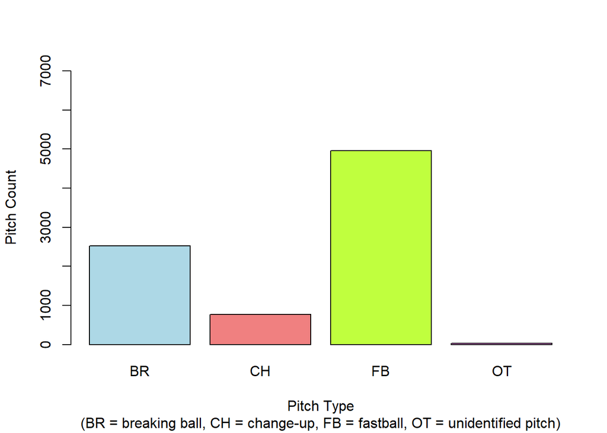

Despite fastballs being the most common pitch type they only make up about 20% of the bangs over the season. Off-speed pitches on the other hand make up approximately 80% of all bangs. This indicates that the Astros were using the trash can banging to signal that the next pitch would be off-speed, as a result when a bang is not heard it most likely means a fastball will be next.

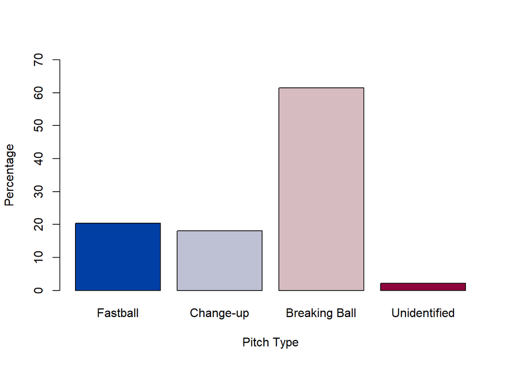

Over the course of the 2017 season we had a range of 1-5 bangs per pitch when a bang was present. This does not seem to indicate any method for signalling as the pitch types for each instance is a mixed bag.

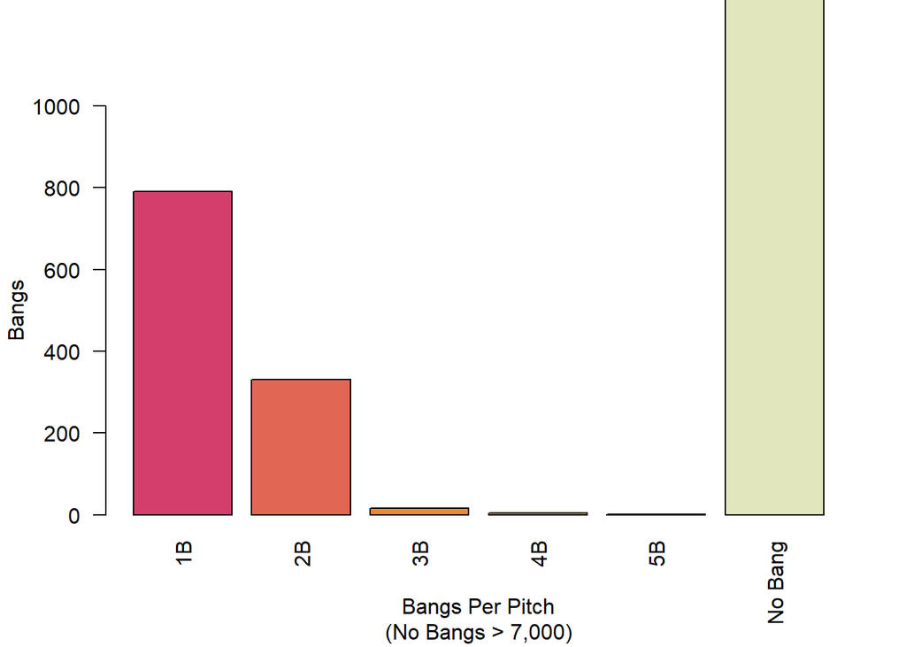

## Techniques For the Data

- One-hot encoding
  - One-hot encoding will be a useful technique for working with the number of bangs that occur for a pitch as well as if a bang was present. Currently the number of bangs that happen for a pitch are characters formatted as “1B” for one bang, “2B” for two bangs, etc. and a if a bang was present is formatted as a character “y” or “n”. The utilization of one-hot encoding will ensure that when these values are turned into binary the algorithm will not try to rank them which would cause multitudes of errors.
- Other
  - I am confident more techniques will become useful as my project proceeds but so far my research has not turned up anything that is blatantly obvious to implement.

## Observations and Relationships

Looking at the plots above we can see that the occurrence of a bang most often signified that an off-speed pitch would be thrown. If a bang occurs during a pitch there is approximately an 80% chance that the next pitch will most likely be an off-speed pitch such as a curveball or breaking ball. Fastballs make up approximately 20% of bangs but this can be chalked up to human error as well as the opposing team adapting to the situation. There have been times where the catcher will approach the mound to let the pitcher know there is some funny business happening, once this happens the pitcher will often change their signs to try and mitigate the issue. The number of bangs that occur do not seem to indicate any specific call as there is a mixed bag of pitch types for each number of bangs present for the pitch, this is most likely due to the person banging on the trash can having different tendencies than the other or possibly accounting for a difference in crowd noise. If a bang was present the occurrence of one bang was the most common occurring more than all other values combined.

## Sanity Check

So far all of the data is making sense and is in an appropriate format. None of the values are negative or counter-intuitive although it would seem more logical to have some of the values as integers rather than characters. I do not see this being a major issue as after implementing one-hot encoding they will be altered to some degree.

## What To Do Next

Next I will begin more in-depth research on neural networks and possibly try to implement some low-level tasks to begin creating the neural net. In the coming weeks I will begin to have a better understanding of how my project should progress but in the meantime I intend to perform some self-study on the subject.